# Lab 08: Heteroskedasticity

## Plotting CI, PI, and data

Here we plot the credible and predictive intervals, using code adapted from Exercise 11 from the EF_activities repository and the Lesson 14 slides.

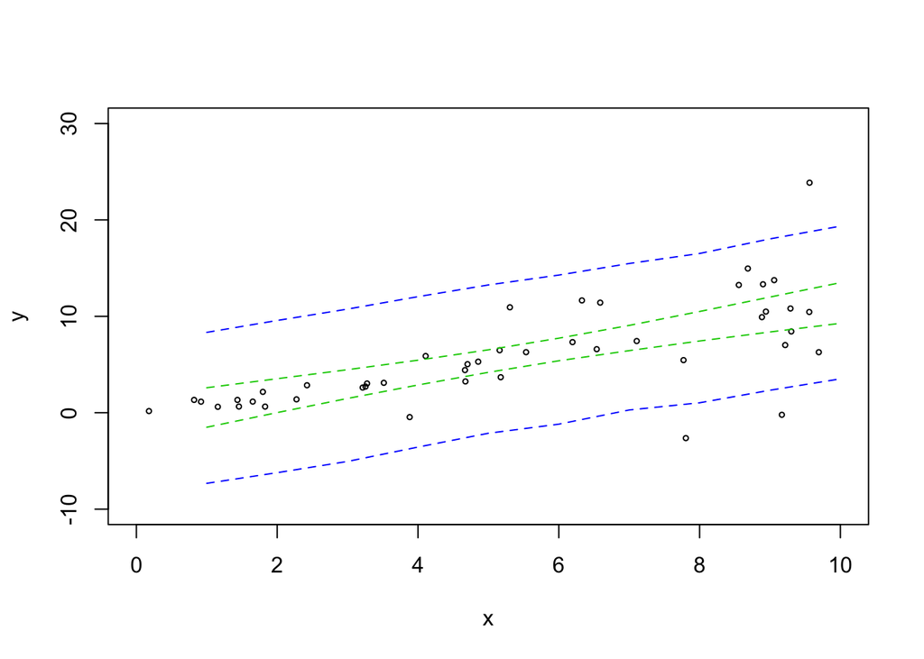

```r
b1 <- out[,2]
b2 <- out[,3]
S <- out[,1]

xpred <- 1:10
npred <- length(xpred)
ycred <- matrix(NA,nrow=nrow(out),ncol=10)
ypred <- matrix(NA,nrow=nrow(out),ncol=10)

for(g in 1:nrow(out)){
  ycred[g,] <- b1[g] + b2[g] * xpred
  ypred[g,] <- rnorm(npred,ycred[g,],1/sqrt(S[g]))
}

ci <- apply(ycred,2,quantile,c(0.025,0.975))  ## credible interval and median
pi <- apply(ypred,2,quantile,c(0.025,0.975))        ## prediction interval
plot(x,y,cex=0.5,xlim=c(0,10),ylim=c(-10,30))
lines(xpred,ci[1,],col=3,lty=2) ## lower CI
lines(xpred,ci[2,],col=3,lty=2) ## upper CI
lines(xpred,pi[1,],col=4,lty=2) ## lower PI
lines(xpred,pi[2,],col=4,lty=2) ## upper PI
```

## Calculate model selection metrics

### DIC

```r
DIC.ho <- dic.samples(j.model, n.iter=5000)
DIC.ho
```

```
## Mean deviance:  249.2
## penalty 3.1
## Penalized deviance: 252.3
```

### WAIC

First, within the JAGS model, add the likelihood calculation within your for loop

```
 like[i] <- dnorm(y[i],mu[i],S)
```

```r
# re-running jags call to include likelihood, with same burn-in settings
jags.out2   <- coda.samples (model = j.model,
                            variable.names = c("b","S","like"),
                                n.iter = 5000)
jags.burn2 <- window(jags.out2,start=burnin)  ## remove burn-in
out2 <- as.matrix(jags.burn2)

   like   <- out2[,grepl("^like",colnames(out2))]
   fbar   <- colMeans(like)
   Pw     <- sum(apply(log(like),2,var))
   WAIC.ho   <- -2*sum(log(fbar))+2*Pw
   WAIC.ho
```

```
## [1] 254.8251
```

You’ll also notice that out output now has a lot of `like` columns that complicate a lot of our other `coda` diagnostics. We can also use `grepl` to *exclude* all the columns that have a pattern. For example:

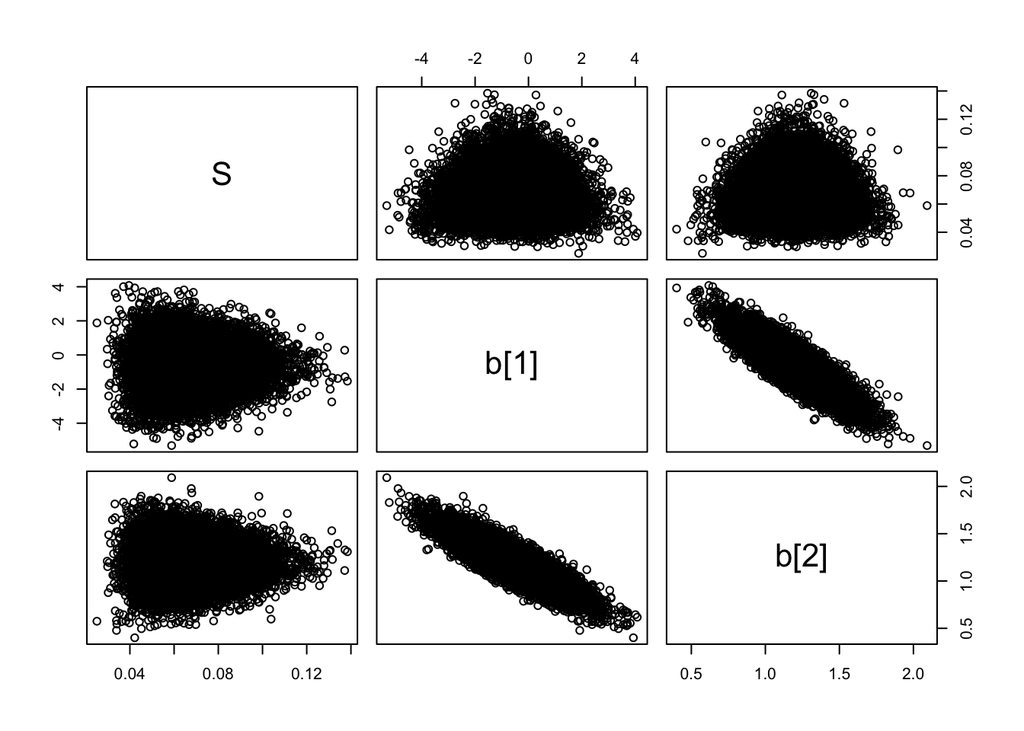

```r
pairs(out2[,!grepl("^like",colnames(out2))])
```

### Predictive loss

The code for predictive loss is very similar to our code for generating confidence and predictive intervals, with the biggest different being that the calculations are done at the OBSERVED X’s not a sequence of X’s (though if you sort your X’s you can often use that sequence to draw the CI & PI).

```r
ngibbs = 3000
yobs  <- y[order(x)]
xpred <- x[order(x)]
npred <- length(xpred)
ypred <- matrix(NA,nrow=ngibbs,ncol=npred)
ycred <- matrix(NA,nrow=ngibbs,ncol=npred)
for(g in 1:ngibbs){
  ycred[g,] <- out[g,2] + out[g,3] * xpred
  ypred[g,] <- rnorm(npred,ycred[g,],sqrt(1/out[g,1]))
}

## Residual variance
ybar <- apply(ycred,2,mean)
G <- sum((yobs-ybar)^2)/npred

## Predictive variance
P <- sum(apply(ypred,2,var))/npred
Dpl <- G + P
PL.ho <- c(G,P,Dpl)
PL.ho
```

```
## [1] 13.89559 15.72824 29.62383
```

Note: for these metrics I’ve added `.ho` onto the end of the name for the homoskedastic model. For the heteroskedastic model you’ll want to change this to something different (e.g. `.he`) so that you don’t overwrite the results from your first models (you’ll need both to make the table at the end)

# Fit heteroskedastic model

To add heteroskedasticity, we’ll start with the linear regression model and then modify it as follows: * Within the JAGS `for` loop, add a process model for the calculation of the precision

```
  s[i] <- a[1] + a[2]*x[i]  ## linear model on standard deviation
  S[i] <- 1/s[i]^2          ## calculate precision from SD
```

- Replace prior on `S` with priors on `a[1]` and `a[2]`. To ensure that our variance is always positive, make sure to choose zero-bound prior distributions on `a`. Don’t forget to add any new prior parameters to your `data` list.
- Update data model and WAIC likelihood calculation to use `S[i]` instead of a fixed `S`.
- Update your `coda.samples` to include `a` instead of `S`.
- As before, perform your standard MCMC metrics & diagnostics
- Calculate your three model selection metrics (DIC, WAIC, PL) ** For predictive loss, CI, and PI, don’t forget to update your process model to include the process model on sigma and to make sure you’re grabbing the right parameters! And don’t forget the precision vs SD difference between R and JAGS.
- Plot your model and data with CI and PI
- As a final task, make a table that shows the different model selection metrics for both models. Briefly discuss how the metrics performed, what they told us, and where they are the same or different.

```r
he.model <- "
  model{

  b ~ dmnorm(b0,Vb)     ## multivariate Normal prior on vector of regression params
  a[1] ~ dlnorm(a0,Va)      ## log Normal prior on precision params
  a[2] ~ dlnorm(a0,Va)      ## log Normal prior on precision params

  for(i in 1:n){
      mu[i] <- b[1] + b[2]*x[i]     ## process model
      y[i]  ~ dnorm(mu[i],S[i])       ## data model

    s[i] <- a[1] + a[2]*x[i]  ## linear model on standard deviation
    S[i] <- 1/s[i]^2          ## calculate precision from SD
    like[i] <- dnorm(y[i],mu[i],S[i]) # likelihood (added for WAIC)
  }
}
"

data <- list(x = x, y = y, n = length(y),
             b0 = as.vector(c(0,0)),   ## regression b mean priors
             Vb = solve(diag(10000,2)),   ## regression b precision priors
             a0 = 0.1,                    ## error prior
             Va = 0.1)                    ## error prior

## initial conditions
inits <- list()
for(i in 1:3){
 inits[[i]] <- list(b = rnorm(2,0,5),
                    a = rlnorm(2,0.1,.1))}

j.model.he   <- jags.model (file = textConnection(he.model),
                             data = data,
                             inits = inits,
                             n.chains = 3)
jags.out.he   <- coda.samples (model = j.model.he,
                              variable.names = c("b","a"), # no likelihood till later so that our diagnostics don't get crowded
                                n.iter = 5000)
```

Basic model diagnostics:

```r
gelman.diag(jags.out.he) ## GBR stats are all less than 1.1, but could be better
```

```
## Potential scale reduction factors:
##
##      Point est. Upper C.I.
## a[1]       1.03       1.05
## a[2]       1.00       1.00
## b[1]       1.00       1.01
## b[2]       1.00       1.00
##
## Multivariate psrf
##
## 1.01
```

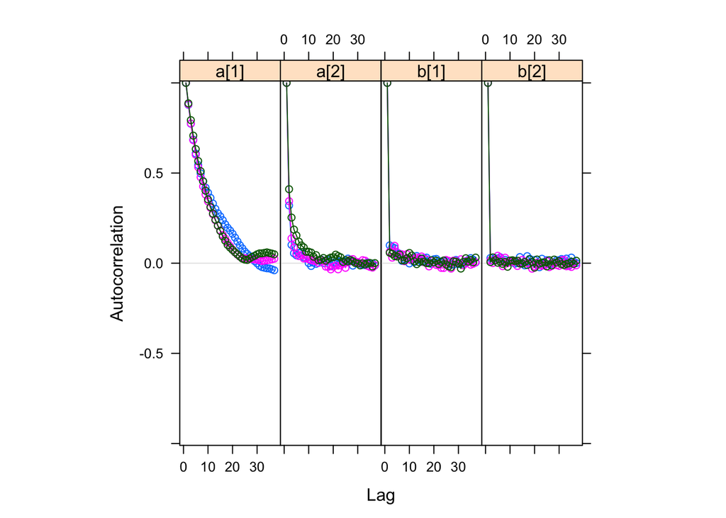

```r
acfplot(jags.out.he) ## Autocorrelation is high for parameter a[1], with a lag of at least 10
```

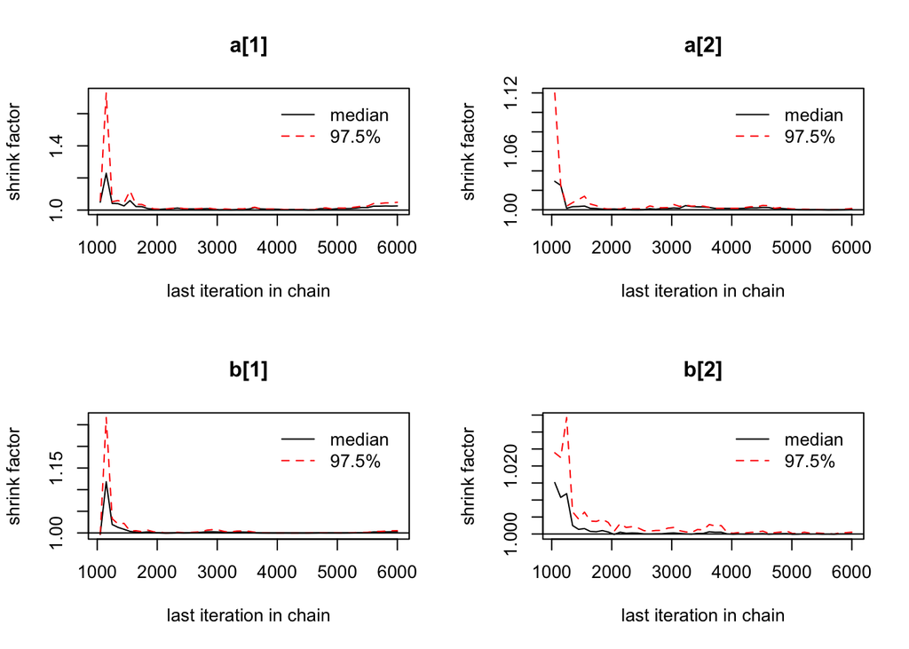

```r
gelman.plot(jags.out.he) ## looks like we should remove about 5k as burn-in
```

```r
burnin = 5000
jags.burn.he <- window(jags.out.he,start=burnin,thin=10)  ## remove burn-in, and thin by 10 samples
effectiveSize(jags.burn.he)
```

```
##     a[1]     a[2]     b[1]     b[2]
## 196.1351 233.7647 303.0000 303.0000
```

The effective size is very low (less than 1k), so let’s take more samples, and include the “like” parameter for WAIC.

```r
# re-running jags call to include likelihood, with same burn-in settings
jags.out.he2   <- coda.samples (model = j.model.he,
                                variable.names = c("b","a","like"),
                                n.iter = 20000, thin = 10)
jags.burn.he2 <- window(jags.out.he2,start=burnin)  ## remove burn-in
out.he2 <- as.matrix(jags.burn.he2)  ## Convert to matrix for later
```

### DIC for heteroskedastic model

```r
DIC.he <- dic.samples(j.model.he, n.iter=5000)
DIC.he
```

```
## Mean deviance:  205.1
## penalty 4.238
## Penalized deviance: 209.3
```

### Predictive loss for heteroskedastic model

```r
# new storage matrices
ngibbs <- 5000
yobs  <- y[order(x)]
xpred <- x[order(x)]
npred <- length(xpred)
ypred <- matrix(NA,nrow=ngibbs,ncol=npred)
ycred <- matrix(NA,nrow=ngibbs,ncol=npred)
s <- matrix(NA,nrow=ngibbs,ncol=npred)

b1   <- out.he2[,grepl("b[1]",colnames(out.he2), fixed=T)]
b2   <- out.he2[,grepl("b[2]",colnames(out.he2), fixed=T)]
a1   <- out.he2[,grepl("a[1]",colnames(out.he2), fixed=T)]
a2   <- out.he2[,grepl("a[2]",colnames(out.he2), fixed=T)]

for(g in 1:ngibbs){
  ycred[g,] <- b1[g] + b2[g] * xpred ## linear model on predictions
  s[g,] <- a1[g] + a2[g]*xpred  ## linear model on standard deviation
  ypred[g,] <- rnorm(npred,ycred[g,],s[g,])
}

## Residual variance
ybar <- apply(ycred,2,mean)
G <- sum((yobs-ybar)^2)/npred

## Predictive variance
P <- sum(apply(ypred,2,var))/npred
Dpl <- G + P
PL.he <- c(G,P,Dpl)
PL.he
```

```
## [1] 14.17582 11.92394 26.09976
```

### WAIC for heteroskedastic model

```r
like   <- out.he2[,grepl("^like",colnames(out.he2))]
fbar   <- colMeans(like)
Pw     <- sum(apply(log(like),2,var))
WAIC.he   <- -2*sum(log(fbar))+2*Pw
WAIC.he
```

```
## [1] 208.4957
```

Plot data and CI/PI using similar code from our predictive loss calculation:

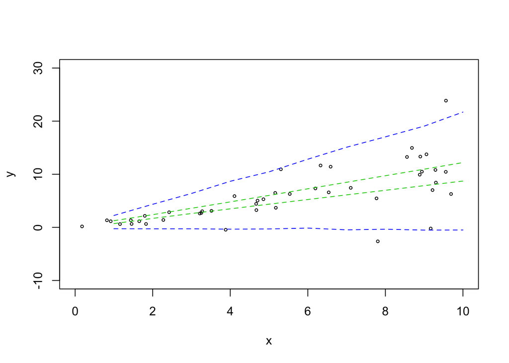

```r
xpred <- 1:10
npred <- length(xpred)
ypred <- matrix(NA,nrow=ngibbs,ncol=npred)
ycred <- matrix(NA,nrow=ngibbs,ncol=npred)
s <- matrix(NA,nrow=ngibbs,ncol=npred)

b1   <- out.he2[,grepl("b[1]",colnames(out.he2), fixed=T)]
b2   <- out.he2[,grepl("b[2]",colnames(out.he2), fixed=T)]
a1   <- out.he2[,grepl("a[1]",colnames(out.he2), fixed=T)]
a2   <- out.he2[,grepl("a[2]",colnames(out.he2), fixed=T)]

for(g in 1:ngibbs){
  ycred[g,] <- b1[g] + b2[g] * xpred  ## linear model on predictions
  s[g,]     <- a1[g] + a2[g] * xpred  ## linear model on standard deviation
  ypred[g,] <- rnorm(npred,ycred[g,],s[g,])
}

ci <- apply(ycred,2,quantile,c(0.025,0.975))  ## credible interval and median
pi <- apply(ypred,2,quantile,c(0.025,0.975))        ## prediction interval
plot(x,y,cex=0.5,xlim=c(0,10),ylim=c(-10,30))
lines(xpred,ci[1,],col=3,lty=2) ## lower CI
lines(xpred,ci[2,],col=3,lty=2) ## upper CI
lines(xpred,pi[1,],col=4,lty=2) ## lower PI
lines(xpred,pi[2,],col=4,lty=2) ## upper PI
```

Looks like our new predictive interval, from the heteroskedastic-variance model does a much better job at capturing our observed y values!

The model selection results from the two models are also quite different:

```r
df <- data.frame(DIC = c(sum(DIC.ho$deviance), sum(DIC.he$deviance)),
                 WAIC = c(WAIC.ho, WAIC.he),
                 PL.G = c(PL.ho[[1]], PL.he[[1]]),
                 PL.P = c(PL.ho[[2]], PL.he[[2]]),
                 PL.D = c(PL.ho[[3]], PL.he[[3]]), row.names = c("homoskedastic","heteroskedastic")
                 )
print(df)
```

```
##                      DIC     WAIC     PL.G     PL.P     PL.D
## homoskedastic   249.1978 254.8251 13.89559 15.72824 29.62383
## heteroskedastic 205.0702 208.4957 14.17582 11.92394 26.09976
```

In this output, we see that the heteroskedastic-variance model performs better across each metric: it has lower DIC, lower WAIC, and lower total Predictive Loss (the last column, PL.D). DIC and WAIC take into account model complexity, so they indicate that the improvement brought by the additional heteroskedastic-model parameters is worth the parameter penalty.

Interestingly, the two models differ in the respective contributions of each component of Predictive Loss. PL.G (residual variance) is about the same for both models, because they have very similar mean estimates. However, in the homoskedastic model, the predictive variance (PL.P) is a higher proportion of PL.D (53%, compared to 46% for the heteroskedastic model). This reflects that treating variance as a function of x-values allows us to tailor our intervals to better suit the data - leading to a much tighter CI/PI at the lower x values, rather than the intervals being constant + wider to fit the spread at the high x values.